# Analiza Cen Akcji firmy Palantir

Filip Misiak, Adam Kowalczyk

2025-05-31

## Charakterystyka danych

Dane dotyczące akcji spółki Palantir Technologies Inc. (ticker: PLTR) zostały pobrane z serwisu Yahoo Finance. Zawierają one informacje o cenach akcji notowanych na giełdzie NASDAQ.

Częstotliwość danych: dzienna Dane są rejestrowane w dniach roboczych giełdy (tj. od poniedziałku do piątku, z wyłączeniem dni świątecznych). Każdy wpis odpowiada jednemu dniowi notowań giełdowych.

Zakres czasowy: Dane obejmują okres od 1 stycznia 2021 roku, co daje ponad 1000 obserwacji dziennych cen.

Zmienna analizowana: Analizie poddano cenę zamknięcia akcji (Close), czyli wartość, po jakiej zakończył się dany dzień notowań.

Inne dostępne zmienne (niewykorzystane bezpośrednio w modelowaniu): - Open – cena otwarcia - High – najwyższa cena dnia - Low – najniższa cena dnia - Volume – liczba wymienionych akcji - Adjusted Close – cena zamknięcia skorygowana o wypłaty (np. dywidendy)

Braki danych: Zbiór danych nie zawiera braków w zakresie dni roboczych giełdy. Nieobecność wpisów w niektóre dni wynika z przerw w notowaniach (weekendy i święta), co jest typowe dla danych giełdowych. W samym szeregu cen zamknięcia brak wartości NA.

## Dzienna ceny zamknięcia Palantir

```
##            PLTR.Open PLTR.High PLTR.Low PLTR.Close PLTR.Volume PLTR.Adjusted
## 2021-01-04     23.91     24.50    22.50      23.37    44970400         23.37
## 2021-01-05     23.18     24.67    22.89      24.60    29050400         24.60
## 2021-01-06     24.12     24.46    23.25      23.54    32732900         23.54
## 2021-01-07     24.02     25.19    23.67      25.00    32240000         25.00
## 2021-01-08     25.70     26.44    24.70      25.20    41313800         25.20
## 2021-01-11     24.61     26.60    24.31      25.93    32609000         25.93
```

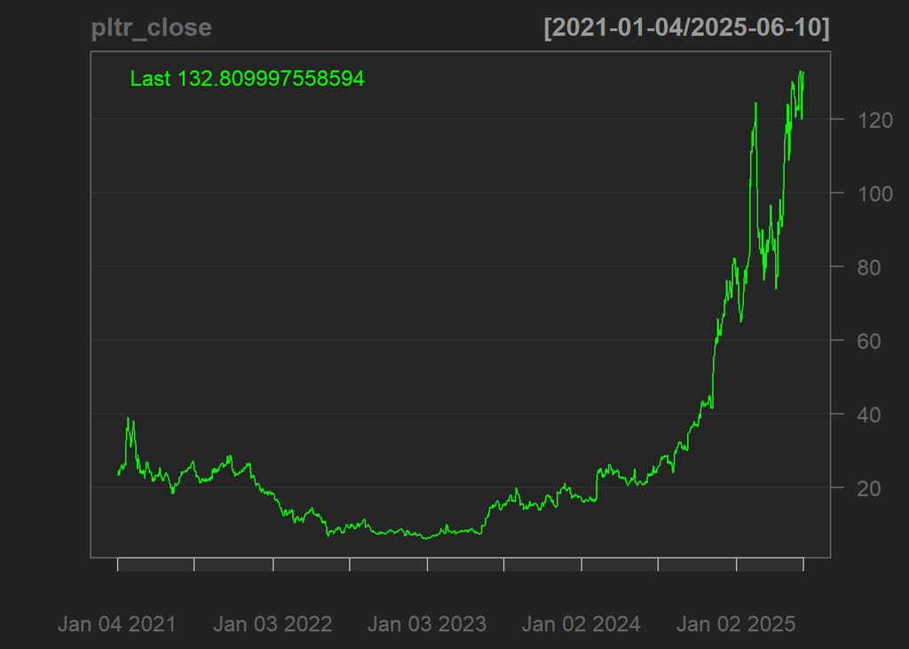

## Dobór metod analizy odpowiadającej celowi badania

Celem analizy było zbudowanie modelu umożliwiającego prognozowanie przyszłych dziennych cen zamknięcia akcji spółki Palantir Technologies Inc. (PLTR). Ponieważ dane mają charakter jednowymiarowego szeregu czasowego o częstotliwości dziennej, zastosowano metody klasyczne.

W pierwszej kolejności wykonano analizę stacjonarności szeregu – warunku koniecznego do zastosowania wielu modeli predykcyjnych, takich jak ARIMA. Wykorzystano wykres danych, test Dickeya-Fullera (ADF) oraz analizę funkcji autokorelacji (ACF) i częściowej autokorelacji (PACF). Sprawdzono także, czy szereg jest białym szumem, stosując test Ljunga-Boxa.

W kolejnym kroku wykorzystano model ARIMA (AutoRegressive Integrated Moving Average). Model ARIMA(p,d,q) łączy w sobie składniki autoregresyjne (AR), różnicowanie (I – integrację) oraz składniki średniej ruchomej (MA). Wybrano go ze względu na jego zdolność do modelowania szeregów niestacjonarnych, po uprzednim ich różnicowaniu.

Dodatkowo dla celów porównawczych zastosowano metodę wygładzania wykładniczego Holt-Wintersa, która dobrze sprawdza się przy prognozowaniu danych wykazujących trend. Metoda ta pozwala na uwzględnienie zmian poziomu oraz trendu szeregu w czasie, a także zapewnia prostą interpretację parametrów.

## Stacjonarność

Stacjonarność szeregu czasowego oznacza, że jego właściwości statystyczne (średnia, wariancja, autokorelacja) nie zmieniają się w czasie. Jest to kluczowe założenie wielu modeli (np. ARIMA), ponieważ niestacjonarne szeregi mogą prowadzić do błędnych prognoz. Aby sprawdzić stacjonarność, stosuje się test Dickeya-Fullera (ADF)

## Test Dickeya-Fullera (ADF)

Test ADF sprawdza hipotezę zerową, że szereg ma jednostkowy pierwiastek, czyli jest niestacjonarny. Jeśli wartość p-value < 0.05, odrzucamy hipotezę zerową i uznajemy szereg za stacjonarny.

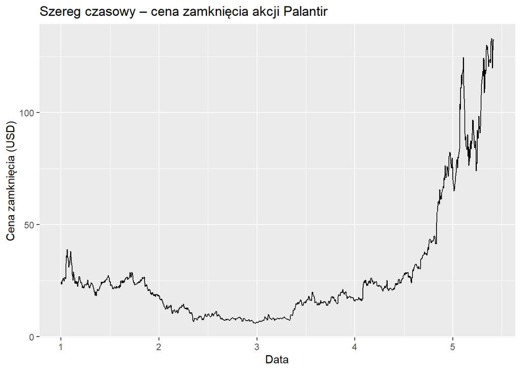

```
##
##  Augmented Dickey-Fuller Test
##
## data:  pltr_ts
## Dickey-Fuller = 0.77572, Lag order = 10, p-value = 0.99
## alternative hypothesis: stationary
```

## Hipotezy testowe:

H0 szereg jest niestacjonary, zawiera pierwiastek jednostkowy. H1 szereg jest stacjonarny.

## Interpretacja:

Ponieważ p-value wynosi **0.99**, a więc znacznie przekracza próg istotności (np. 0.05), **nie ma podstaw do odrzucenia hipotezy zerowej**. Oznacza to, że szereg czasowy `pltr_close` **jest niestacjonarny**.

## Wnioski:

Szereg **wymaga przekształcenia**, najczęściej różnicowania (ang. *differencing*), aby osiągnąć stacjonarność. Po różnicowaniu należy ponownie przeprowadzić test ADF, by sprawdzić, czy szereg po przekształceniu stał się stacjonarny.

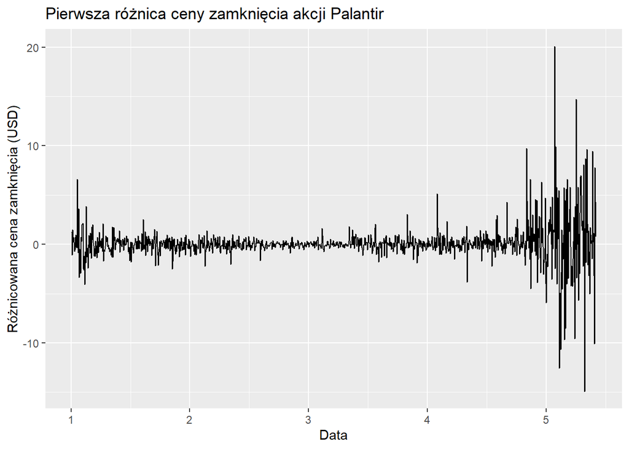

```
##
##  Augmented Dickey-Fuller Test
##
## data:  pltr_diff_clean
## Dickey-Fuller = -10.229, Lag order = 10, p-value = 0.01
## alternative hypothesis: stationary
```

## Analiza i interpretacja wyników po różnicowaniu

p-value: Jest mniejsze niż 0.01, co potwierdza, że wynik jest istotny statystycznie na poziomie istotności 1% (czyli z bardzo wysoką pewnością odrzucamy H0).

Wniosek: Po pierwszym różnicowaniu szeregu czasowego ceny zamknięcia akcji Palantir możemy odrzucić hipotezę zerową o niestacjonarności.

Implikacje dla dalszej analizy:

Oryginalny szereg był niestacjonarny (p-value ≈ 0.99), więc nie nadawał się do klasycznych metod modelowania szeregów czasowych, jak np. ARMA czy ARIMA bez różnicowania.

## Autokorelacja (ACF) i częściowa autokorelacja (PACF)

ACF (Autocorrelation Function) pokazuje, jak bieżące wartości szeregu są skorelowane z jego przeszłymi wartościami w różnych opóźnieniach (lagach). Pomaga zidentyfikować sezonowość lub długookresowe zależności.

PACF (Partial Autocorrelation Function) usuwa wpływ wcześniejszych lagów i pokazuje bezpośrednią korelację danego laga z bieżącą wartością.

W praktyce, wykresy ACF i PACF służą do doboru parametrów modeli ARIMA – np. liczby opóźnień autoregresyjnych (AR) i średnich ruchomych (MA).

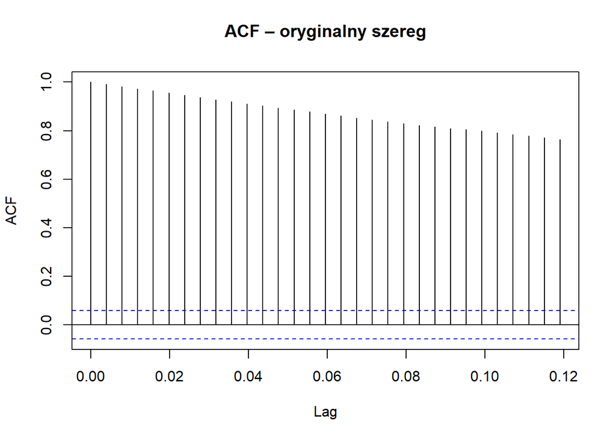

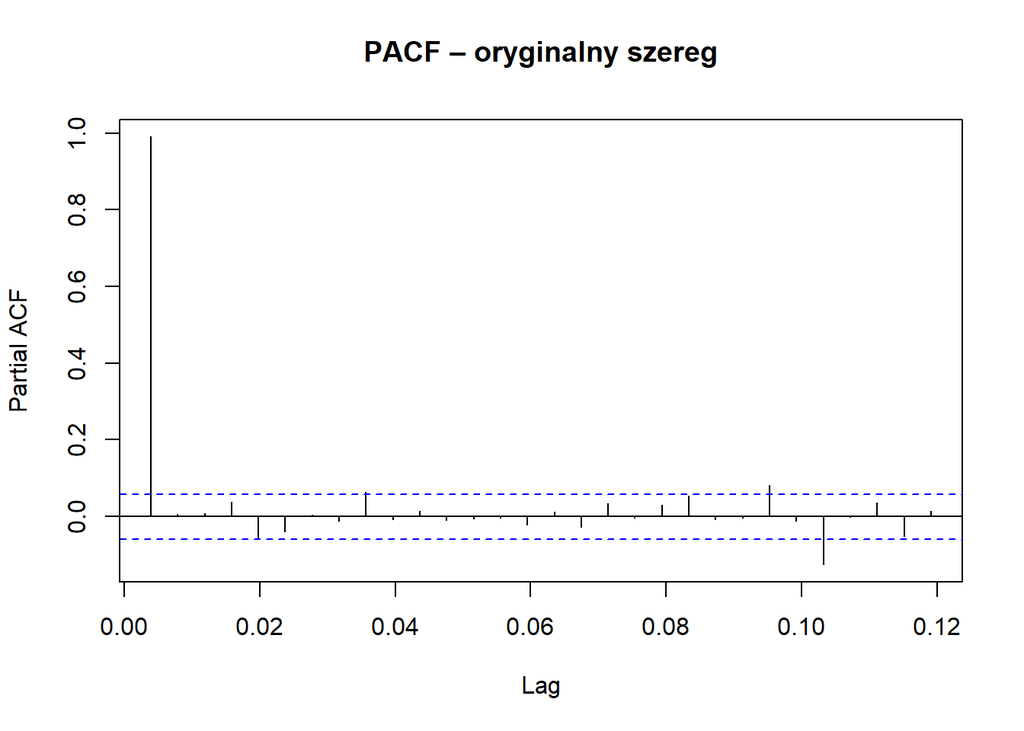

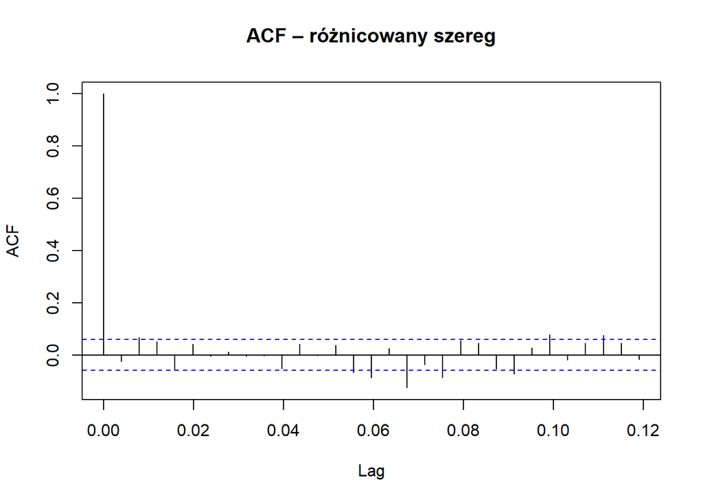

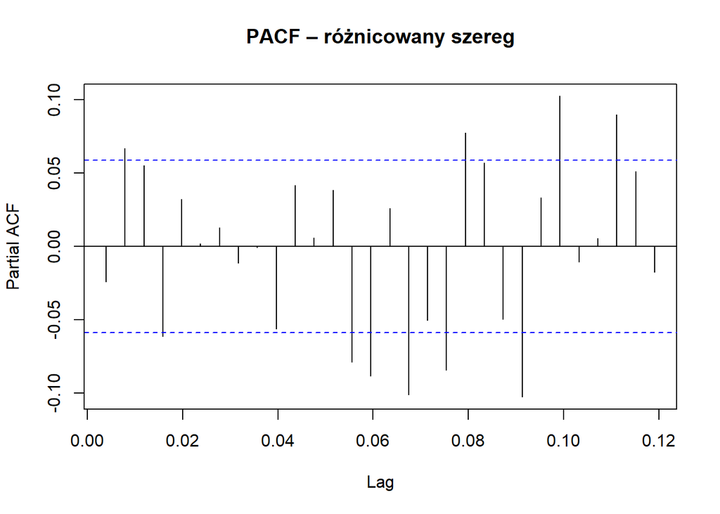

AUTOKORELACJA: Na pierwszym wykresie ACF dla oryginalnego szeregu zauważyć można wysoką autokorelacja na wszystkich lagach (wartości są bardzo blisko liczby 1). Charakterystyczny powolny spadek wskazuje na silną niestacjonarność szeregu. Zatem przeszłe wartości bardzo mocno wpływają na obecne. Wniosek: szereg nie jest stacjonarny i wymaga różnicowania.

Na wykresie PACF dla oryginalnego szeregu , duża wartość występuje tylko dla laga 1 a pozostałe są bardzo blisko zera. Jest to charakterystyczne zachowanie dla procesu z komponentem autoregresyjnym (AR) rzędu 1. Wniosek: może to sugerować model ARIMA(1,d,0) ale najpierw trzeba usunąć niestacjonarność.

Na podstawie wykresu PACF z różnicowanym szeregiem zaobserwować można kilka lagów poza granicami istotności, ale nie można zaobserwować wyraźnego schematu. Wniosek: PACF nie wskazuje jednoznacznie na obecność składnika AR- możliwy jest model ARIMA(0,1,1) lub pokrewne.

## Test Ljunga-Boxa

Test Ljunga-Boxa sprawdza, czy pozostałości (reszty) modelu są niezależne, czyli czy model dobrze dopasował strukturę zależności w danych. Hipoteza zerowa mówi, że reszty są nieskorelowane (tzw. biały szum). Wysokie p-value (np. > 0.05) oznacza, że nie ma istotnych autokorelacji – model jest poprawny.

```
##
##  Box-Ljung test
##
## data:  na.omit(pltr_diff_clean)
## X-squared = 67.273, df = 20, p-value = 5.045e-07
```

## Interpretacja wyniku:

Hipoteza zerowa (H0): Dane są białym szumem — wartości są niezależne, brak autokorelacji. Hipoteza alternatywna (H1): Dane nie są białym szumem — występuje autokorelacja.

Ponieważ p-value jest ekstremalnie małe (znacznie poniżej 0.05), odrzucamy hipotezę zerową. Oznacza to, że różnicowany szereg pltr_diff_clean nie jest białym szumem i zawiera istotne zależności autokorelacyjne. Innymi słowy, w danych dalej istnieje struktura, którą można modelować

## Sprawdzenie sezonowości

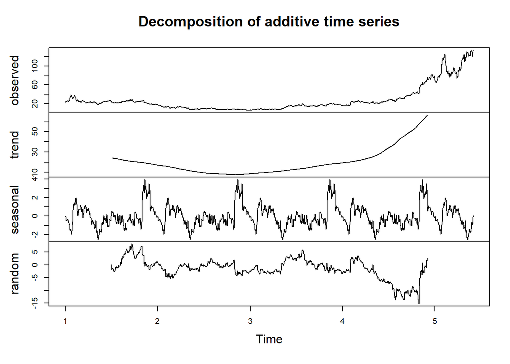

```
## [1] 13
```

## Wynik

Można z dużym prawdopodobieństwem uznać, że dane nie zawierają istotnej sezonowości.

W takim przypadku: ARIMA bez komponentu sezonowego będzie odpowiednia. ETS może automatycznie dobrać komponenty, ale nie musi zawierać sezonowości.

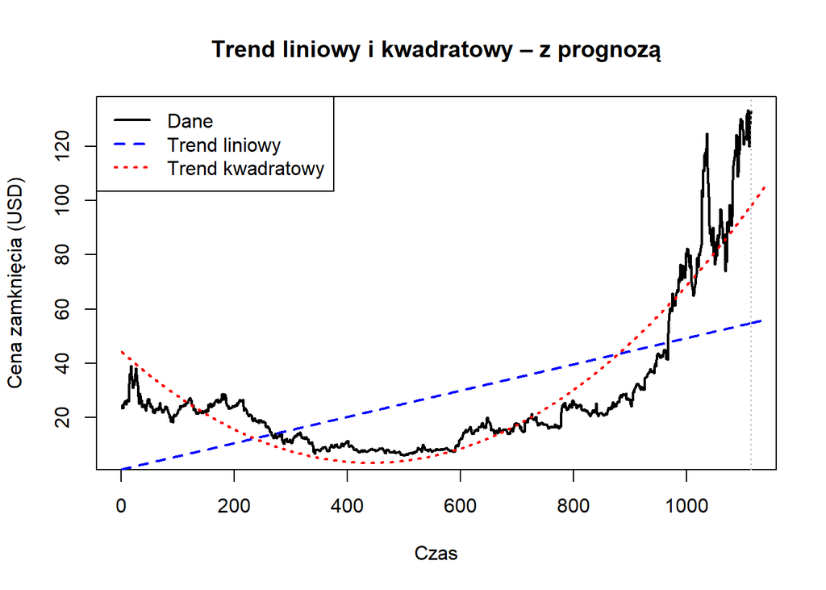

Trend liniowy reprezentuje stałe tempo wzrostu cen w czasie.

Tend kwadratowy uzględnia nielionwy przebieg danych pozwalając na modelowanie spadków czy silnych wzrostów.

## Wynik

Dane wykazują wyraźny nieliniowy wzorzec: początkowy spadek a następnie gwałtowny wzrost.

Model kwadratowy lepiej odwzorowuje charakterystykę danych hisotrycznych i przewiduje przyszłość w sposób bardziej zgodny z obserwowanym przyspieszeniem cen.

Model liniowy może być pomocny jako punkt odniesienia, ale w tym przypadku niedoszacowuje późniejsze wartości i ignoruje dynamikę rynku. Średni ogólny kierunek jest dobrze oddany, ale nie uchwyca zakrzywienia linii ani okresów stagnacji

## Modele ARIMA

Model ARIMA(p,d,q) to połączenie trzech komponentów:

AR(p) – autoregresja: szereg zależy liniowo od własnych przeszłych wartości

I(d) – różnicowanie: ile razy należy odjąć szereg od siebie, by uzyskać stacjonarność

MA(q) – średnia ruchoma: szereg zależy liniowo od przeszłych błędów prognozy

Przykład: ARIMA(1,1,1) oznacza, że dane są jednokrotnie różnicowane i dopasowano jeden składnik AR i jeden MA.

```
## Series: train_ts
## ARIMA(1,2,0)
##
## Coefficients:
##           ar1
##       -0.5976
## s.e.   0.0244
##
## sigma^2 = 3.736:  log likelihood = -2247.99
## AIC=4499.97   AICc=4499.98   BIC=4509.95
##
## Training set error measures:
##                       ME     RMSE      MAE        MPE     MAPE       MASE
## Training set 0.003070664 1.930068 1.000288 0.01616264 3.841781 0.05292301
##                    ACF1
## Training set -0.1728934
```

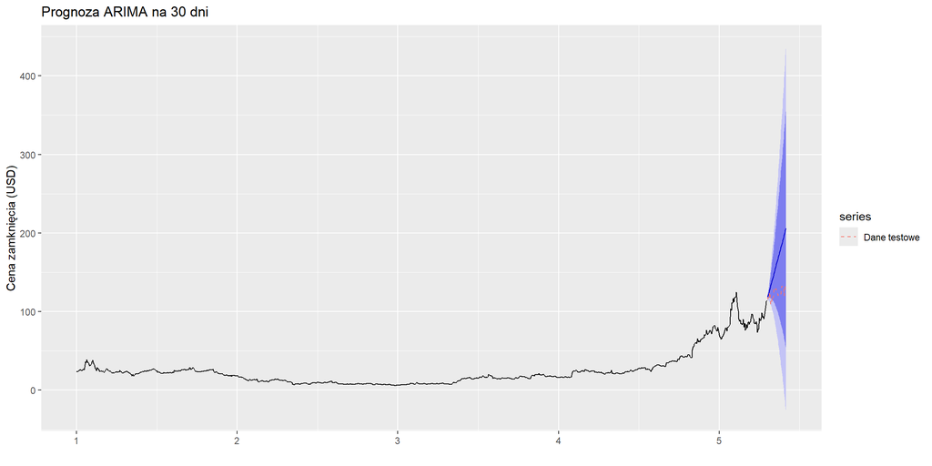

```
##                         ME      RMSE       MAE          MPE      MAPE
## Training set   0.003070664  1.930068  1.000288   0.01616264  3.841781
## Test set     -38.358822086 44.549355 38.358822 -30.59360822 30.593608
##                    MASE       ACF1 Theil's U
## Training set 0.05292301 -0.1728934        NA
## Test set     2.02947955  0.8859046  8.266466
```

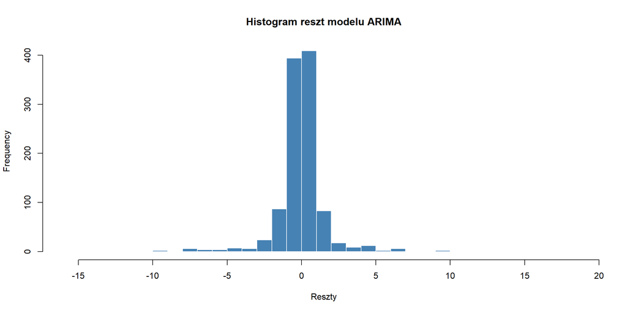

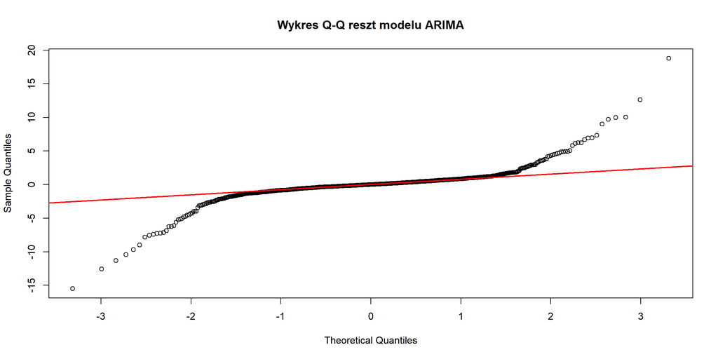

## Obserwacje na podstawie wyników dla danych treningowych:

Niski RMSE = 1,93 oznacza niski błąd na danych uczących. Niski MAPE = 3,84% oznacza że model bardzo dobrze odwzorowuje dane treningowe

## Obserwacje z histogramu reszt i wykresu Q-Q reszt:

Histogram nie prezentuje zbyt silnych wartości odstających. Rozkład jest wyraźnie skupiony wokół zera co oznacza, że model nie zaniża ani nie zawyża prognoz.

Na wykresie Q-Q widać, że większość danych leży blisko czerwonej lini, zatem jest zgodna z rozkładem normalnym. Występują nielizczne wartości odstające widoczne na począrku i na końcu wykresu.

## Obserwacje na podstawie prognozy ARIMA:

Dane testowe wykazały wzrost jak prognoza- jednakże na wykresie zauważyć można znaczne przesacowanie tych przyszłych wartości na okres 30 dni. Wyniko to z faktu że model ARIMA najlepiej radzi sobie z krótkoterminowymi prognozami.

## Wygładzanie wykładnicze – model ETS

Metoda ETS (Error, Trend, Seasonality) opiera się na wygładzaniu wykładniczym, gdzie większą wagę przypisuje się nowszym obserwacjom. W modelu Holt-Wintersa rozróżniamy trzy komponenty:

Addytywny lub multiplikatywny trend

Addytywna lub multiplikatywna sezonowość

Losowy składnik błędu

W R model ten można zastosować poprzez funkcję HoltWinters() lub ets().

```
##
## Forecast method: STL +  ETS(A,Ad,N)
##
## Model Information:
## ETS(A,Ad,N)
##
## Call:
## ets(y = na.interp(x), model = etsmodel, allow.multiplicative.trend = allow.multiplicative.trend)
##
##   Smoothing parameters:
##     alpha = 0.9063
##     beta  = 0.1037
##     phi   = 0.8
##
##   Initial states:
##     l = 24.1644
##     b = 0.3717
##
##   sigma:  1.4492
##
##      AIC     AICc      BIC
## 8386.833 8386.911 8416.764
##
## Error measures:
##                      ME     RMSE       MAE        MPE     MAPE       MASE
## Training set 0.06170134 1.445888 0.8325986 0.04338911 4.085141 0.04405093
##                     ACF1
## Training set -0.01135897
##
## Forecasts:
##          Point Forecast     Lo 80    Hi 80     Lo 95    Hi 95
## 5.301587       108.2190 106.36173 110.0763 105.37855 111.0594
## 5.305556       109.3021 106.68951 111.9147 105.30649 113.2977
## 5.309524       109.6634 106.39684 112.9299 104.66764 114.6591
## 5.313492       109.6866 105.82504 113.5481 103.78087 115.5923
## 5.317460       110.0861 105.67205 114.5001 103.33539 116.8368
## 5.321429       110.1989 105.26629 115.1314 102.65514 117.7426
## 5.325397       110.5436 105.12123 115.9659 102.25082 118.8363
## 5.329365       110.9921 105.10513 116.8791 101.98875 119.9955
## 5.333333       110.0470 103.71760 116.3764 100.36703 119.7269
```

[output cut: 480 more lines]

[output not shown]

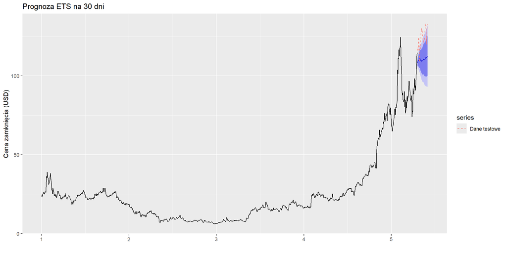

```
##                       ME      RMSE        MAE         MPE      MAPE       MASE
## Training set  0.06170134  1.445888  0.8325986  0.04338911  4.085141 0.04405093
## Test set     13.42793086 14.717913 13.5214254 10.61490247 10.700731 0.71538840
##                     ACF1 Theil's U
## Training set -0.01135897        NA
## Test set      0.60219076  2.720899
```

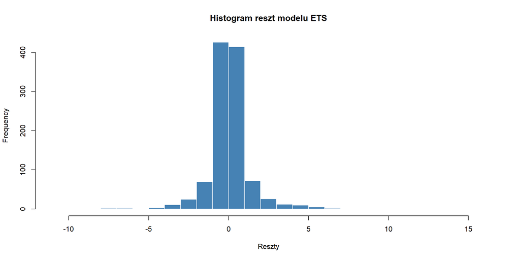

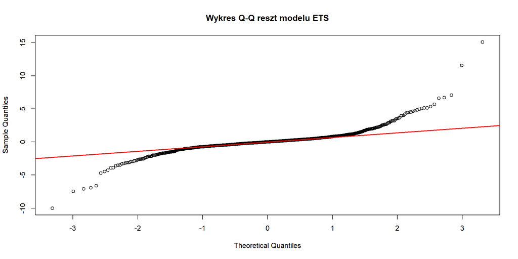

## Obserwacje na podstawie wyników dla danych treningowych:

MAPE= 4% i RMSE= 1,4 w danych treninigowych jest zbliżony do tego z ARIMA ale testowe wartości są znacznie mniejsze od tych z modelu ARIMA

Zatem ETS lepiej poradził sobie z prognozą.

## Obserwacje z histogramu reszt i wykresu Q-Q reszt:

Histogram nie prezentuje zbyt silnych wartości odstających. Reszty są symetryczne. Rozkład jest wyraźnie skupiony wokół zera co oznacza, że model nie zaniża ani nie zawyża prognoz.

Na wykresie Q-Q widać, że większość danych leży blisko czerwonej lini, zatem jest zgodna z rozkładem normalnym. Występują nielizczne wartości odstające widoczne na począrku i na końcu wykresu.

Histogram reszt modelu ETS i wykres reszt modelu ETS wykazują podobne tendencje jak te wykresy dla modelu ARIMA- z jedynym zauważalnym mniejszym odstępem od normalności na początku wykresu

## Obserwacje na podstawie prognozy ETS:

Model ETS prognozuje umiarkowany wzrost ale nie nadąża za rzeczywistym dynamicnzym wzrostem. Zauważyć można jednak węższe strefy niepewności niż dla prognozy ARIMA. Można dojść dla wniosku, że okres 30 dni również okazałsię zbyt długim dla tego modelu.